# L08 Positioning

Data Visualization (STAT 302)

Jingyang Zhang

## Overview

The goal of this lab is to develop an understanding of facets, position, continue the exploration of other `ggplot2` options/features.

## Datasets

We’ll be using the `titanic.rda`, `Aus_athletes.rda`, and `cdc.txt` datasets.

```r
# Load package(s)
library(tidyverse)
library(cowplot)

# Load datasets
load("data/titanic.rda")
load("data/Aus_athletes.rda")

# Read in the cdc dataset
cdc <- read_delim(file = "data/cdc.txt", delim = "|") %>%

  mutate(genhlth = factor(genhlth,

    levels = c("excellent", "very good", "good", "fair", "poor"),

    labels = c("Excellent", "Very Good", "Good", "Fair", "Poor")
  ))

# Set seed
set.seed(8221984)

# Selecting a random subset of size 1000
cdc_small <- cdc %>% sample_n(1000)
```

## Exercises

Complete the following exercises.

### Exercise 1

Using the `titanic.rda` dataset, recreate the following graphic as precisely as possible.

*Hints:*

- Hex colors: `#D55E00D0`, `#0072B2D0`

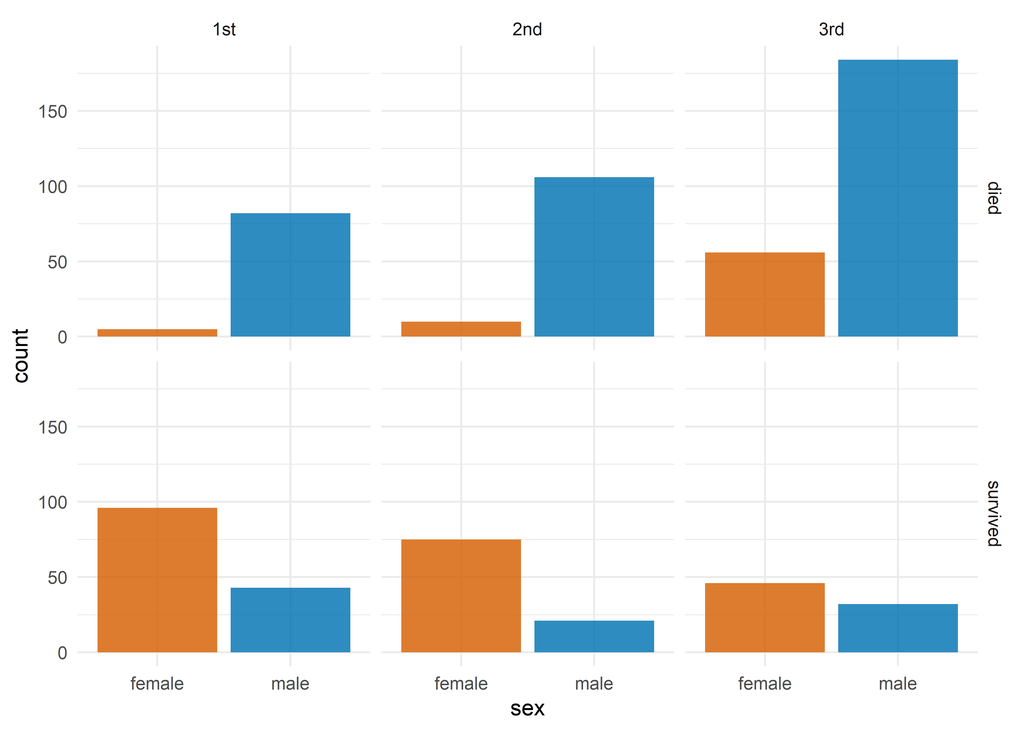

```r
# New facet label names for dose variable
survival.labs <- c("died", "survived")

names(survival.labs) <- c("0", "1")

ggplot(titanic, aes(sex)) +

  geom_bar(aes(fill = sex), show.legend = FALSE) +

  facet_grid(survived ~ class,
             labeller = labeller(survived = survival.labs))+

  scale_fill_manual(values = c("#D55E00D0", "#0072B2D0")) +

  theme_minimal()
```

### Exercise 2

Use the `athletes_dat` dataset — extracted from `Aus_althetes.rd` — to recreate the following graphic as precisely as possible. The `cowplot` package will be useful.

```r
# Get list of sports played by BOTH sexes
both_sports <- Aus_athletes %>%

  distinct(sex, sport) %>%

  count(sport) %>%

  filter(n == 2) %>%

  pull(sport)

# Process data
athletes_dat <- Aus_athletes %>%

  filter(sport %in% both_sports) %>%

  mutate(sport = case_when(

    sport == "track (400m)" ~ "track",

    sport == "track (sprint)" ~ "track",
    TRUE ~ sport
    )
  )
```

*Hints:*

- Build each plot separately
- Use [`cowplot::plot_grid()`](https://cran.r-project.org/web/packages/cowplot/vignettes/plot_grid.html) to combine them
- Hex values for shading: `#D55E0040` and `#0072B240` (bottom plot), `#D55E00D0` & `#0072B2D0` (for top two plots) — no `alpha`
- Hex values for outline of boxplots: `#D55E00` and `#0072B2`
- Boxplots should be made narrower; 0.5
- Legend is in top-right corner of bottom plot
- Legend shading matches hex values for top two plots
- Bar plot lower limit 0, upper limit 95
- `rcc`: red blood cell count; `wcc`: white blood cell count
- Size 3 will be useful

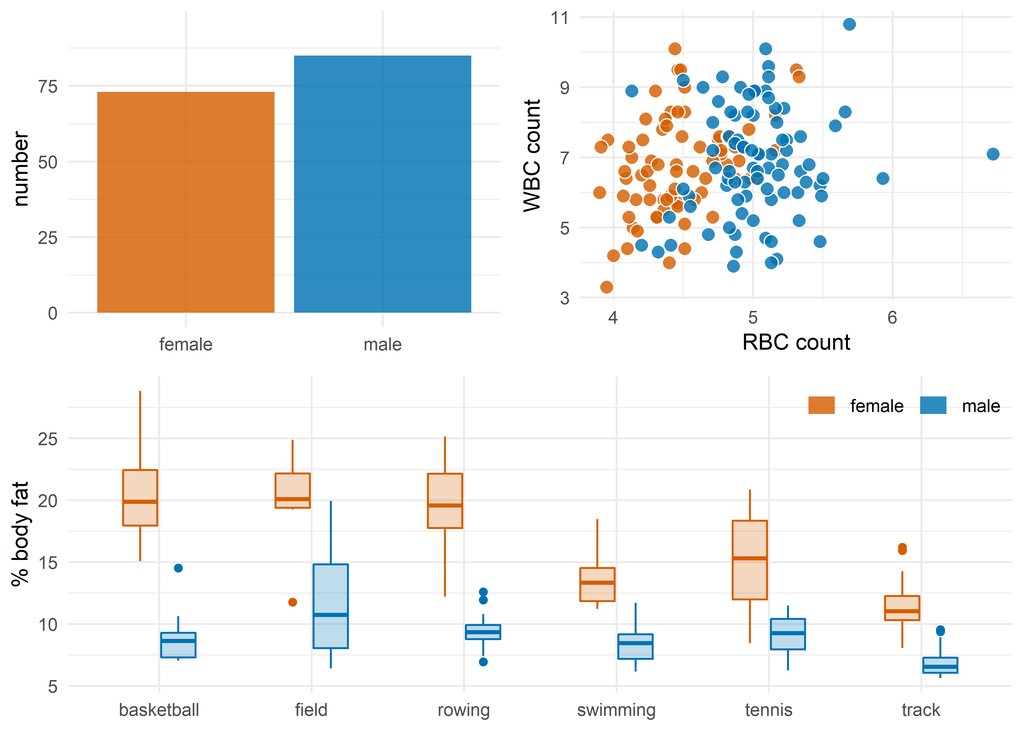

```r
## PLOT 1 ##
exer2_p1 <- ggplot(athletes_dat, aes(sex)) +

  geom_bar(aes(fill = sex), show.legend = FALSE) +

  scale_x_discrete(labels = c("female", "male"),
                   name = NULL) +

  scale_y_continuous(limits = c(0, 95),
                   breaks = seq(0, 95, 25),
                   name = "number") +

  scale_fill_manual(values = c("#D55E00D0", "#0072B2D0")) +

  theme_minimal()


## PLOT 2 ##
exer2_p2 <- ggplot(athletes_dat, aes(rcc, wcc)) +

  geom_point(aes(color = sex, fill = sex),
             shape = 21, size = 3, color = "white",
             show.legend = FALSE)+

  scale_fill_manual(values = c("#D55E00D0", "#0072B2D0")) +

  labs(x = "RBC count", y = "WBC count") +

  theme_minimal()



## PLOT 3 ##
exer2_p3 <- ggplot(athletes_dat, aes(sport, pcBfat)) +

  geom_boxplot(aes(fill = sex, color = sex), width = 0.5) +

  scale_color_manual(values = c("#D55E00", "#0072B2"),
                     labels = c("female", "male"),
           # guide = FALSE is NOT necessary,
           # it is used to turn off one of the legend
                     guide = FALSE ) +

  # the 40 at the end of #D55E00 adds the transparency
  scale_fill_manual(values = c("#D55E0040", "#0072B240"),
                    labels = c("female", "male")) +

  guides(color = guide_legend(override.aes = list(
                    # remove the outline of boxplot
                    color = NA,
                    fill = c("#D55E00D0", "#0072B2D0")))) +
  labs(fill = NULL,  color = NULL,
                    y = "% body fat", x = NULL) +

theme_minimal() +

  theme(legend.position = c(1, 1),
        legend.justification = c(1, 1),
        legend.direction = "horizontal")



## Combine three plots ##

exer2_row1 <- plot_grid(exer2_p1, exer2_p2)

plot_grid(exer2_row1, exer2_p3, ncol = 1)
```

Method 2 of making exer2_p3

```r
exer2_p3 <- ggplot(athletes_dat, aes(sport, pcBfat)) +

  geom_boxplot(aes(fill = sex, color = sex), width = 0.5) +

  scale_color_manual(values = c("#D55E00", "#0072B2"),
                     labels = c("female", "male")) +

  # the 40 at the end of #D55E00 adds the transparency
  scale_fill_manual(values = c("#D55E0040", "#0072B240"),
                    labels = c("female", "male")) +

  guides(fill = guide_legend(override.aes =
                    list(fill = c("#D55E00D0", "#0072B2D0"))),
                    color = guide_legend(override.aes = list(color = c("transparent", "transparent")))) +

  labs(fill = NULL,  color = NULL,
       y = "% body fat", x = NULL) +

theme_minimal() +

  theme(legend.position = c(1, 1),
        legend.justification = c(1, 1),
        legend.direction = "horizontal")
```

### Exercise 3

Using `cdc_small`construct a the following graphic as precisely as possible.

*Hints:*

- Need to do a little more data processing
- Hex values: `"#D55E00D0"` and `#0072B2D0`
- `grey80` might be useful
- size 2

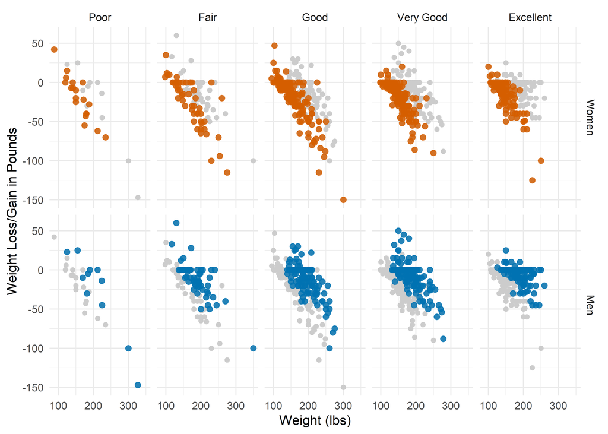

```r
# Add calculated weight change
# Reorder genhlth levels
cdc_small <- cdc_small %>%

  mutate(
    weight_change = wtdesire - weight,

    genhlth_order= factor(genhlth, levels = rev(levels(factor(genhlth))))

  )

gender.labs <- c("Women", "Men")

names(gender.labs) <- c("f", "m")

cdc_small2 <- select(cdc_small, -gender)

ggplot(cdc_small, aes(weight, weight_change)) +

  geom_point(data = cdc_small2, color = "grey80") +

  geom_point(aes(color = gender), size = 2,
             show.legend = FALSE) +

  facet_grid(gender ~ genhlth_order,
             labeller = labeller(gender = gender.labs)) +

  scale_color_manual(values = c("#D55E00D0", "#0072B2D0")) +
  labs(x = "Weight (lbs)" , y = "Weight Loss/Gain in Pounds") +

  theme_minimal()
```